# BIOS 611 HW1 Data visualisation (Chapter 3)

Matthew J Rich

09/05/2018

*This homework is due September 5th 6pm.*

(This set of exercise is mostly taken from R for Data Science by Garrett Grolemund and Hadley Wickham.)

# Exercise 1

1. What’s gone wrong with this code? Why are the points not blue?

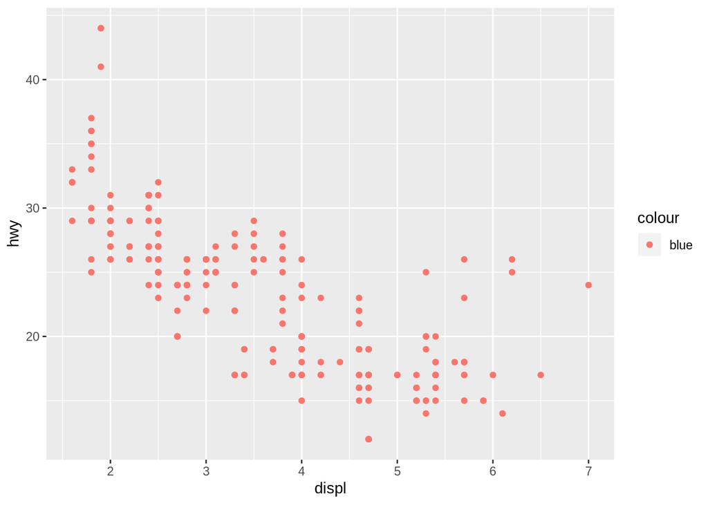

   ```r
   library(ggplot2)
   ggplot(data = mpg) +
     geom_point(mapping = aes(x = displ, y = hwy, color = "blue"))
   ```

   Answer: plot is not blue because manual asctetics must be defined outside AES()

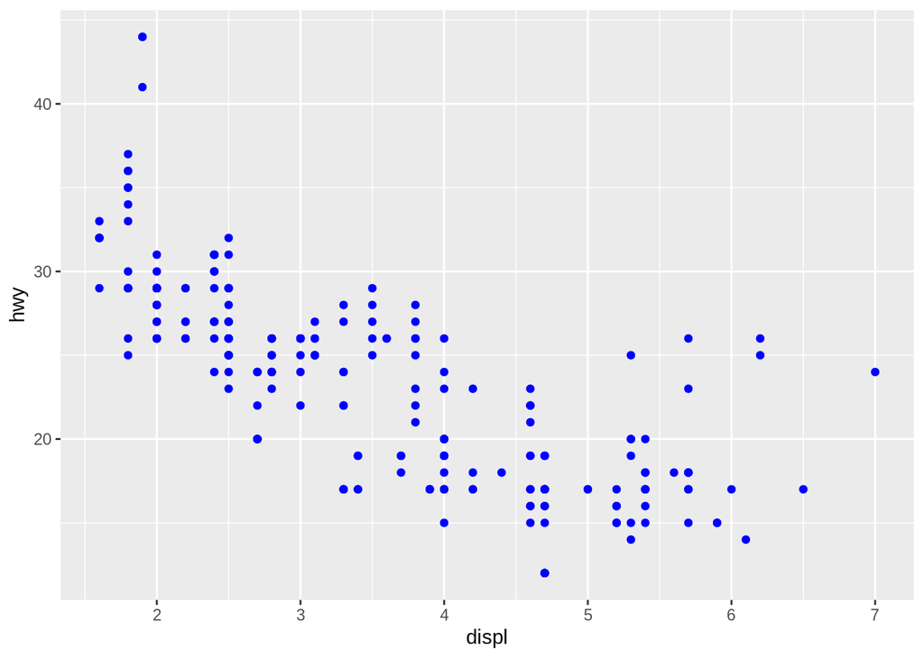

   ```r
     library(ggplot2)
      ggplot(data = mpg) +
     geom_point(mapping = aes(x = displ, y = hwy), color = "blue")
   ```

2. Which variables in `mpg` are categorical? Which variables are continuous? (Hint: type `?mpg` to read the documentation for the dataset). How can you see this information when you run `mpg`?

   Answer: only one column contains real numbers so that is the only continuous data out of the 11 variables present

   ```r
     library(ggplot2)
      df = mpg
       head(df)
   ```

   ```
   ## # A tibble: 6 x 11
   ##   manufacturer model displ  year   cyl trans drv     cty   hwy fl    class
   ##   <chr>        <chr> <dbl> <int> <int> <chr> <chr> <int> <int> <chr> <chr>
   ## 1 audi         a4      1.8  1999     4 auto… f        18    29 p     comp…
   ## 2 audi         a4      1.8  1999     4 manu… f        21    29 p     comp…
   ## 3 audi         a4      2    2008     4 manu… f        20    31 p     comp…
   ## 4 audi         a4      2    2008     4 auto… f        21    30 p     comp…
   ## 5 audi         a4      2.8  1999     6 auto… f        16    26 p     comp…
   ## 6 audi         a4      2.8  1999     6 manu… f        18    26 p     comp…
   ```

3. Map a continuous variable to `color`, `size`, and `shape`. How do these aesthetics behave differently for categorical vs. continuous variables?

   Answer: Only color and size can be mapped to a continuous variable. All three can only handle a few different values before being unable to map.
4. What happens if you map the same variable to multiple aesthetics?

   Answer: you will generate two legends one for each mapping

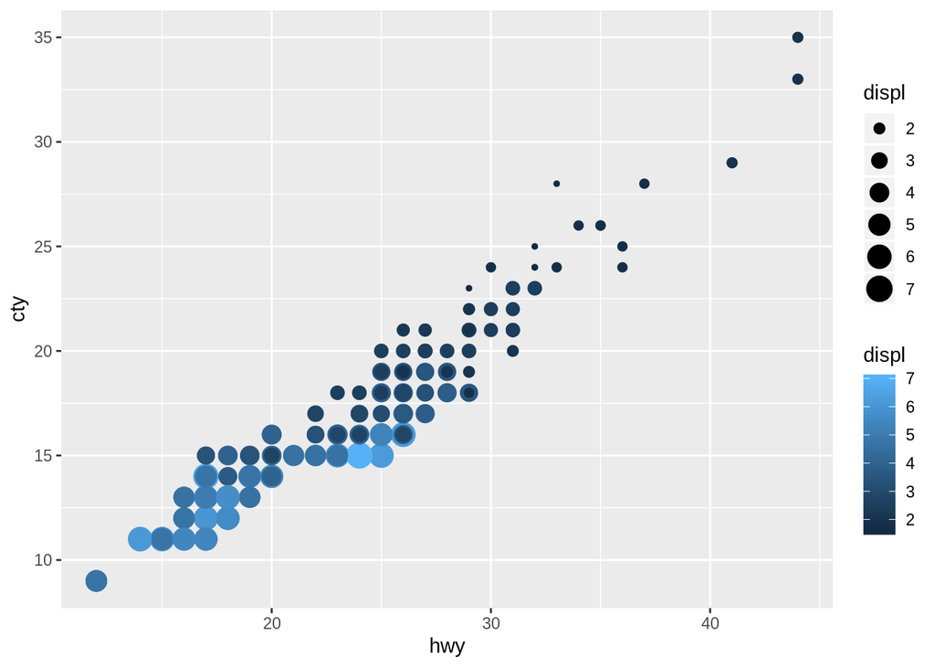

   ```r
     library(ggplot2)
     ggplot(data=mpg) +
     geom_point(mapping = aes(x = hwy, y = cty, color = displ, size = displ))
   ```

5. What does the `stroke` aesthetic do? What shapes does it work with? (Hint: use `?geom_point`)

   Answer: For geom plot the stroke can control the border thickness of a markers if one is present. If the marker does not have a border it functions like size.

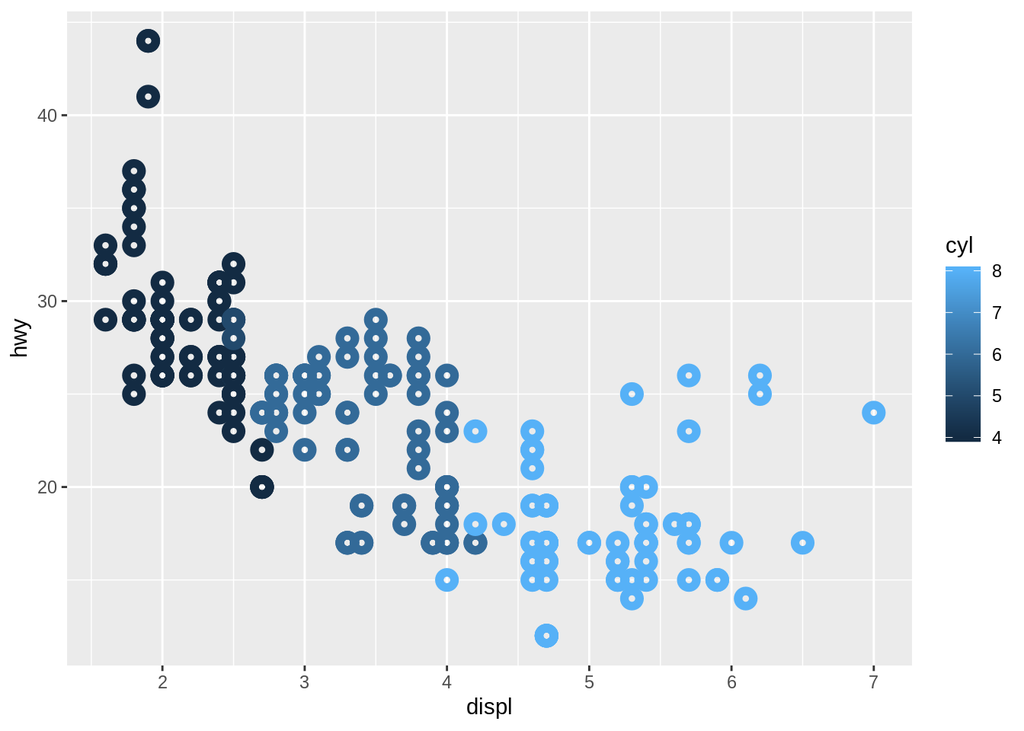

   ```r
     ggplot(data = mpg) +
     geom_point(mapping = aes(x = displ, y = hwy, color = cyl), stroke = 3, shape = 21)
   ```

6. What happens if you map an aesthetic to something other than a variable name, like `aes(colour = displ < 5)`?

   Answer: The mapping will behave as an conditional formatting rule mapping based on which data points cause the expression to be true or falce

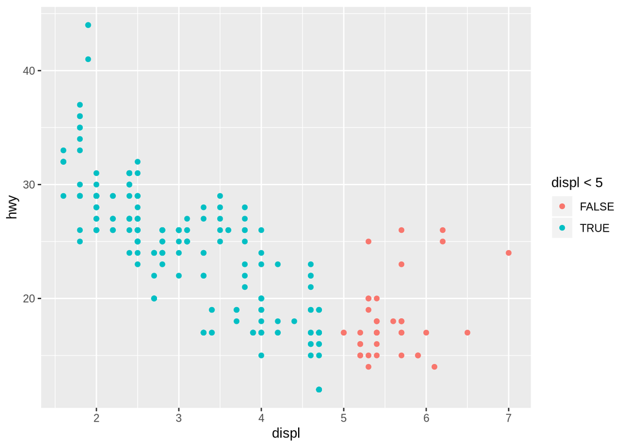

   ```r
      ggplot(data = mpg) +
      geom_point(mapping = aes(x = displ, y = hwy, colour = displ < 5))
   ```

# Exercise 2

1. What do the empty cells in plot with `facet_grid(drv ~ cyl)` mean? How do they relate to this plot?

   ```r
     ggplot(data = mpg) +
     geom_point(mapping = aes(x = drv, y = cyl))
   ```

   Answer: The empty facets represent non existent combinations of engine drive and cylindders.

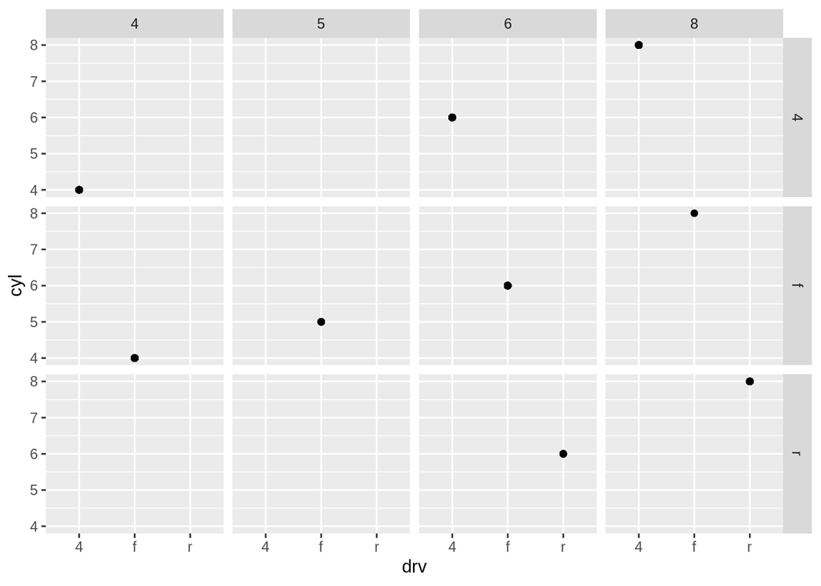

   ```r
     ggplot(data = mpg) +
     geom_point(mapping = aes(x = drv, y = cyl)) +
     facet_grid(drv ~ cyl)
   ```

2. What plots does the following code make? What does `.` do?

   ```r
   ggplot(data = mpg) +
     geom_point(mapping = aes(x = displ, y = hwy)) +
     facet_grid(drv ~ .)

   ggplot(data = mpg) +
     geom_point(mapping = aes(x = displ, y = hwy)) +
     facet_grid(. ~ cyl)
   ```

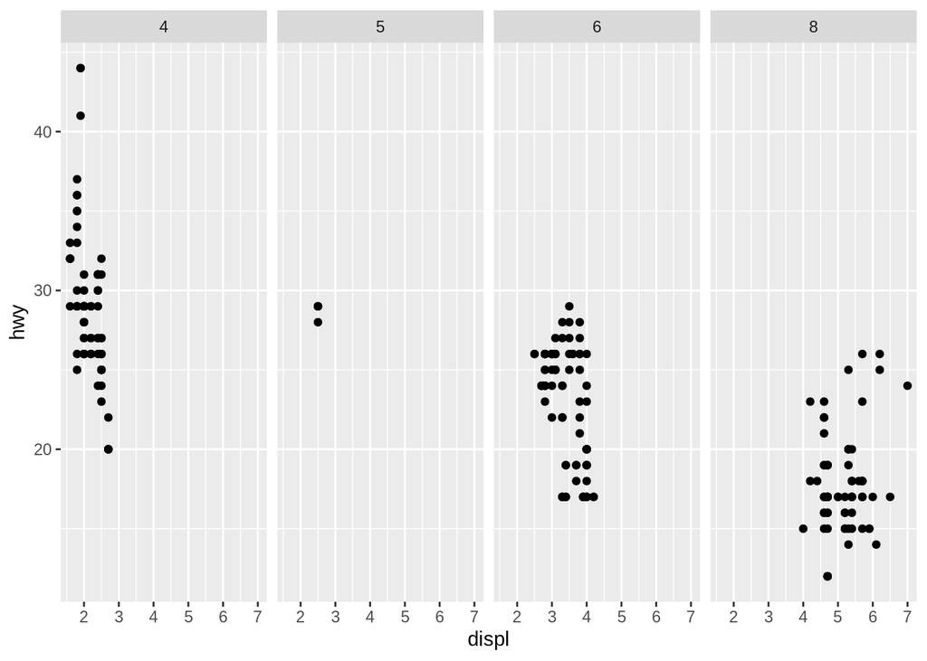

   ```r
     ggplot(data = mpg) +
     geom_point(mapping = aes(x = displ, y = hwy)) +
     facet_grid(. ~ cyl)
   ```

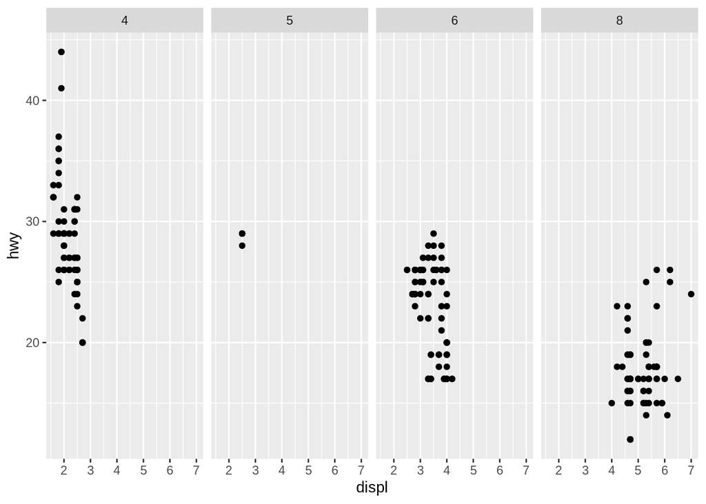

   ```r
     ggplot(data = mpg) +
     geom_point(mapping = aes(x = displ, y = hwy)) +
     facet_wrap( ~ cyl , nrow = 1)
   ```

3. Take the first faceted plot in this section:

   ```r
   ggplot(data = mpg) +
     geom_point(mapping = aes(x = displ, y = hwy)) +
     facet_wrap(~ class, nrow = 2)
   ```

   What are the advantages to using faceting instead of the colour aesthetic? What are the disadvantages? How might the balance change if you had a larger dataset?

   Answer: The advantage is that it is able to isolate a specific class of vehicle, helpful when you have a lot of data points with a great deal of overlap. The downside is understanding the relationship between facets will be harder since they will be plotted separately

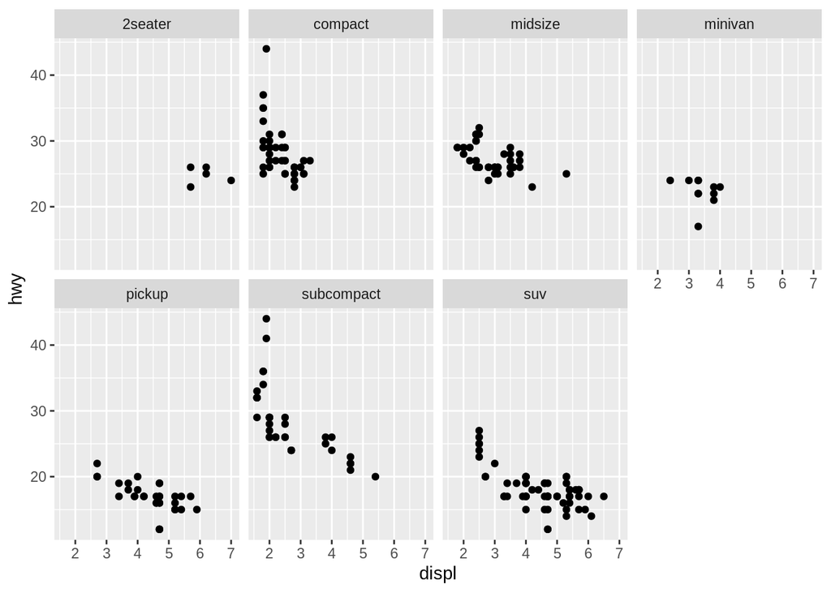

   ```r
   ggplot(data = mpg) +
     geom_point(mapping = aes(x = displ, y = hwy)) +
     facet_wrap(~ class, nrow = 2)
   ```

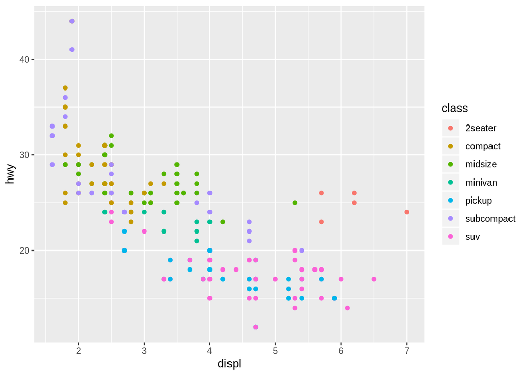

   ```r
     ggplot(data = mpg) +
     geom_point(mapping = aes(x = displ, y = hwy, color = class))
   ```